# Noldus | Advance your behavioral research

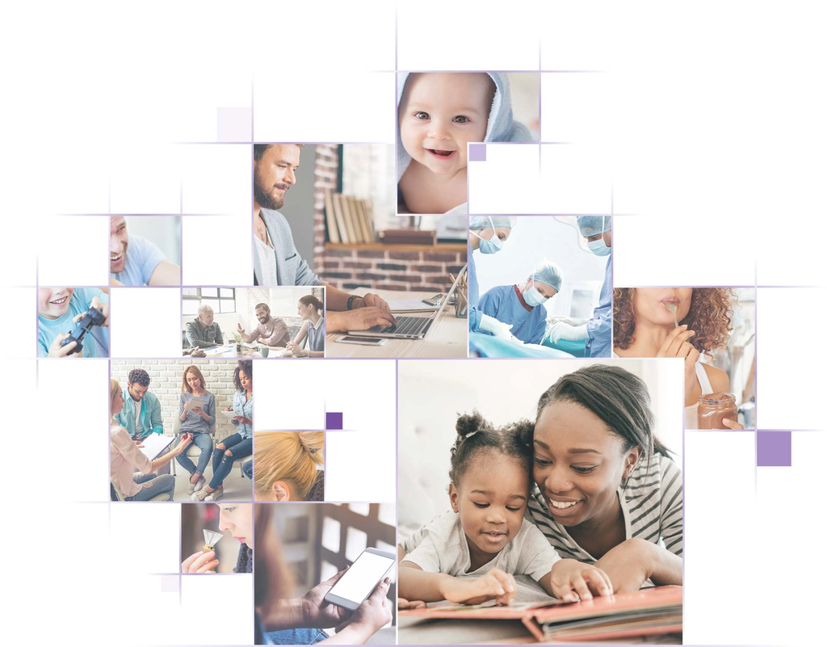

# Advance your behavioral research

## Save time & obtain high quality data

### [Software](https://www.noldus.com/products?id=software)

### [Services](https://www.noldus.com/products?id=services)

### [Labs](https://www.noldus.com/labs)

### [Systems](https://www.noldus.com/products?id=systems)

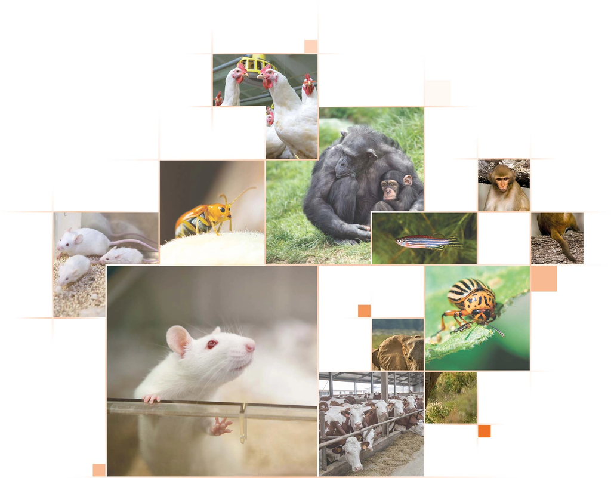

### 3 easy steps

## Kickstart your research

[figure not shown]

1. Tell us about your research challenge. How can we help?

[figure not shown]

2. Our dedicated scientific consultants provide you with a tailored solution.

[figure not shown]

3. With our continuous product developments, we are partners for life.

## Our products

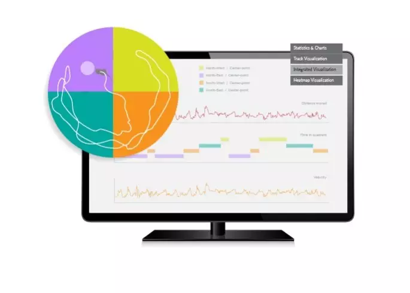

### EthoVision XT

EthoVision XT is the most widely applied video tracking software that tracks and analyzes the behavior, movement, and activity of any animal.

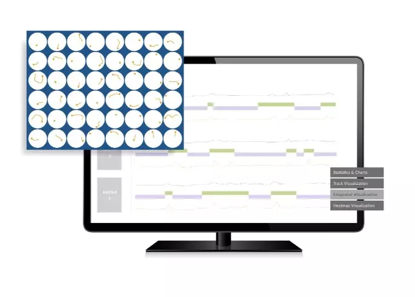

### DanioVision

Looking for a zebrafish larvae research tool? DanioVision is the complete system designed for high-throughput tracking of zebrafish larvae and other small organisms.

[figure not shown]

### CatWalk XT

CatWalk XT is a complete gait analysis system for quantitative assessment of footfalls and locomotion in rats and mice.

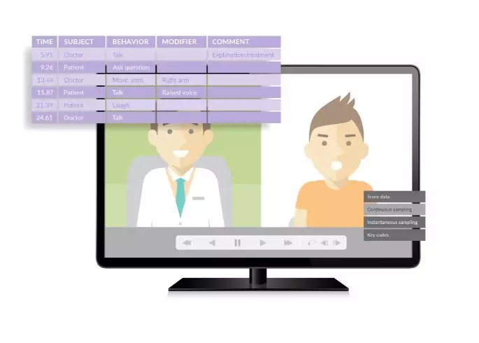

### The Observer XT

Supporting you from coding behaviors on a timeline and unraveling the sequence of events to integrating different data modalities in a complete lab.

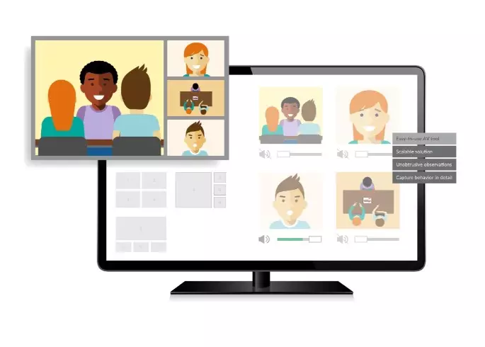

### Viso

Viso is the easy-to-use solution for creating video and audio recordings in order to capture behaviors and interactions of your participants.

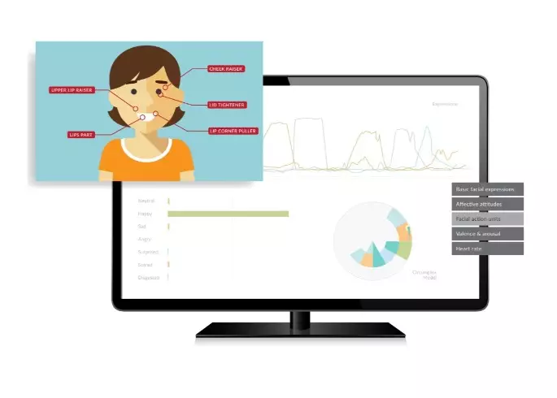

### FaceReader

To gain accurate and reliable data about facial expressions, FaceReader is the most robust automated system that will help you out.

After considerable research, it was clear Noldus was the only option to turn our vision into reality.

S. Shah

Digital of Things

I am continually impressed by the prompt and professional service and support you provide for us.

Prof. S. Campbell

Simon Frasier University

Using The Observer XT saved me months of time. I would buy the software again.

Dr. E. Eadie

University of New Mexico

You make our lives easy. Frankly put, Noldus is the best at its game in the world.

Dr. D. Wolmarans

North-West University, South Africa

We’re so very happy with our purchase, you just wouldn’t believe it!

Prof. E. Glasper

University of Maryland

What I love about Noldus Information Technology is the personal attention and service.

Prof. Dr. D. Pollak

Medical University of Vienna

[figure not shown]

**4.5 stars**  
customer satisfaction

[figure not shown]

**35,000**  
publications

[figure not shown]

**19** offices  
worldwide

[figure not shown]

**50,000** users  
around the globe

## Meet us

07

Jun

[Data Storytelling: A CatWalk XT Tale](https://www.noldus.com/events/data-storytelling-a-catwalkxt-tale)

Webinar

07

Jul

[International congress of Infant Studies 2022](https://www.noldus.com/events/icis-2022)

Conference

09

Jul

[13th FENS Forum of Neuroscience](https://www.noldus.com/events/fens-2022)

Conference

## On-Demand Webinars

Did you miss one of our live talks? Visit our [online library](https://www.noldus.com/webinars) to access them all for free.

Or find an overview of [all events](https://www.noldus.com/events).

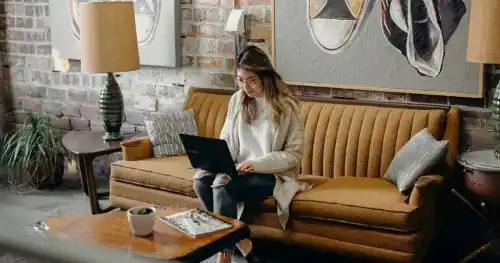

Why you should use FaceReader Online for your human behavior research

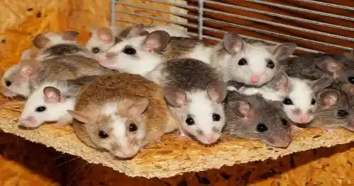

Determining the best housing strategy for mice

News flash

## EthoVision XT 17

The latest evolutions in behavioral tracking have just been released in EthoVision XT 17! Our new AI algorithm for nose-tail detection has been increased to 4 simultaneous arenas. Also software based licensing is among some major advantages. Discover the innovations of the software that will advance your research.

## Support

[MyNoldus](https://my.noldus.com/)  
[NoldusCare](https://www.noldus.com/nolduscare)

## Contact information

### Global Headquarters

Wageningen, the Netherlands

+31-317 473 300

### North American Headquarters

Leesburg, VA, USA

+1-703-771-0440

1-800-355-9541 (toll-free)

info@noldus.com

### Asian Headquarters

Beijing, China

+86-10-84852246

info-china@noldus.com  
[www.noldus.com.cn](https://noldus.com.cn/)